# Análisis Multivariado - Clase 11

2025-10-22

## Datos Longitudinales

## Motivación

Supongamos que tenemos la siguiente base de datos con el PBI de ciertos países de una región del mundo a lo largo de los años.

```
##   ID  Año      PBI
## 1  1 2022 457.2976
## 2  1 2023 435.8594
## 3  1 2024 473.0354
## 4  1 2025 470.0420
## 5  2 2022 407.9377
## 6  2 2023 355.8455
```

Notar que hay algunas medidas repetidas por cada país. Además, podemos contar la cantidad de países:

```r
length(unique(DatSim1$ID))
```

```
## [1] 100
```

## Datos longitudinales

- Se denominan datos longitudinales a datos que consisten de varios individuos, a los que se les realizan algunas mediciones repetidas a lo largo del tiempo.
- Estos datos tienen la complejidad de que los datos no son independientes entre sí (algunos corresponden al mismo individuo).
- A su vez, las mediciones repetidas no suelen ser suficientes para sacar conclusiones precisas sobre la evolución en el tiempo.
- Por otro lado, las evoluciones varían mucho para distintos individuos, y la conclusión que se pueda extraer sobre uno de ellos, puede no aplicar para otro.
- Los individuos se suelen notar con la letra \(i\) y el número de medición con la letra \(j\).

## Trayectorias

Cuando queremos evaluar las evoluciones a lo largo del tiempo, es necesario trazar líneas entre mediciones consecutivas para poder identificar crecimientos y decrecimientos.

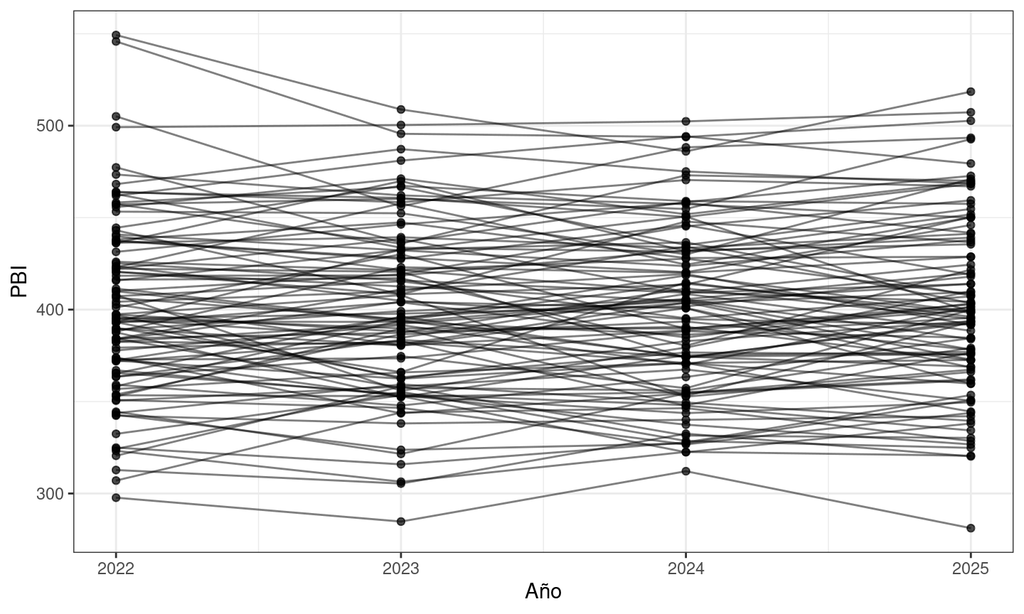

Vemos que hay pocas fluctuaciones, pero el nivel de PBI por país se mantiene relativamente constante.

## Correlación

Este gráfico permite ver cómo los datos están correlacionados entre sí. Cada punto representa el PBI para el mismo país en dos años distintos. No sólo vemos correlación, sino correlación positiva.

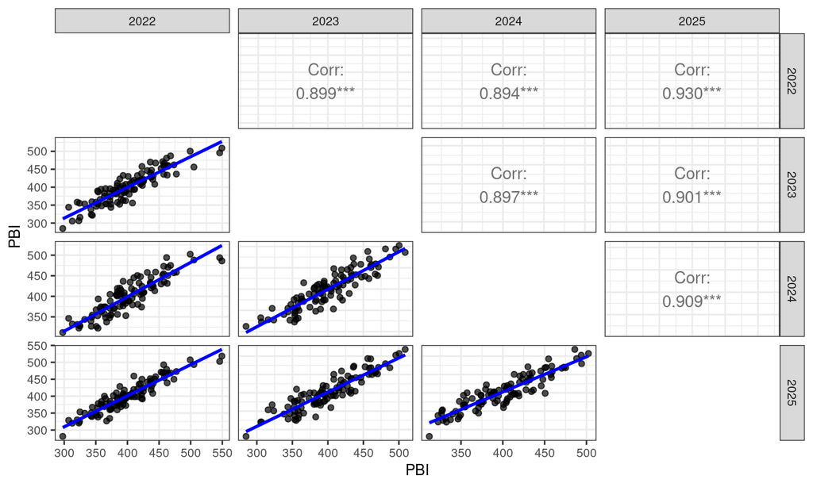

## Efectos fijos

Hay casos donde una variable es de mayor interés para entender su evolución (la llamamos variable de respuesta). En este caso, la variable de mayor interés sería el PBI.

Se llaman covariables a las variables que se usan para explicar la variable de respuesta.

Se llama un modelo de efectos fijos, cuando se considera que las covariables tienen influencia fija sobre la variable de respuesta. Es decir, salvo fluctuaciones considerados en los errores, sólo influye el valor de la covariable en la variable de respuesta.

## Modelo de efectos fijos

En este caso, podríamos considerar que la tendencia en el PBI a lo largo del tiempo es relativamente constante. Es decir, \[PBI_{i,j}=\mu + \varepsilon_{i,j}\] Aquí se asume que los errores son independientes, tienen distribución normal y homoscedástica. Es decir, \(\varepsilon_{i,j}\sim\mathcal{N}(0,\sigma_R^2)\).

En este modelo, se estiman sólo dos parámetros: \(\mu\) y \(\sigma_R\).

## Representación gráfica

Vemos cómo queda la representación de este modelo para los datos:

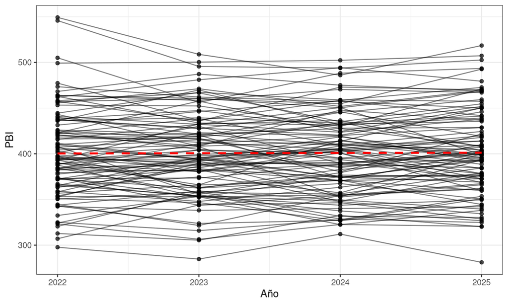

## Variabilidad intersujeto

Se puede observar que el modelo logra representar la tendencia central de los datos, pero no necesariamente es representativa de todas las observaciones. De hecho, veamos el valor del \(R^2\):

```
## [1] 0
```

Es decir, el modelo no explica **NADA** de la varianza de los datos.

Esto se debe a que los datos tienen mucha heterogeneidad y varían mucho por cada país. Por eso, intentar representar las evoluciones con una única constante no termina representando a ninguna.

## Efectos fijos individuales

Se podrían utilizar variables dummies por país para plantear un modelo en el que cada país tiene un PBI relativamente constante. Es decir, cada variable dummy tiene un efecto fijo sobre el PBI: \[PBI_{i,j}=\mu_i + \varepsilon_{i,j}\]

Esto introduce 100 parámetros para estimar (una media por país), además del desvío de los errores \(\sigma_R\).

## Representación gráfica

Vemos que en este caso, el modelo se adapta bien a la heterogeneidad de los datos.

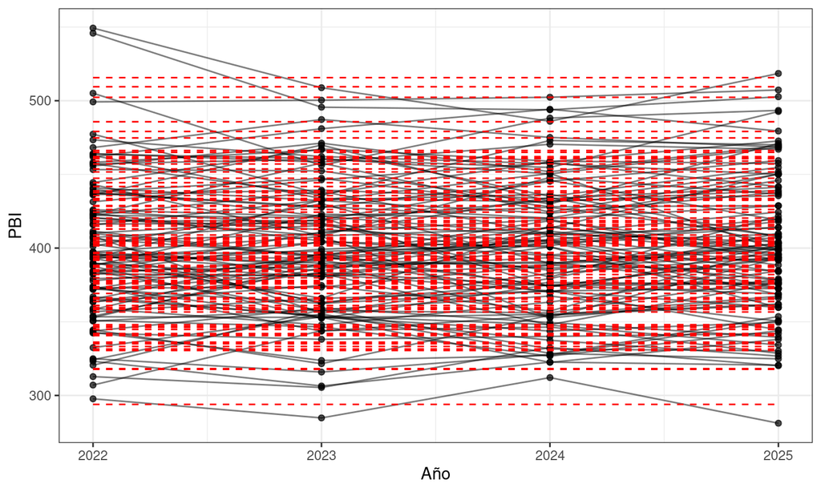

## Efectos fijos individuales

También esta representación se visualiza en el \(R^2\):

```
## [1] 0.9278236
```

## Efectos Aleatorios

Una forma de evitar estos problemas es introduciendo lo que se llaman “Efectos Aleatorios”.

Lo que busca este planteo es considerar un efecto \(b_i\) de cada individuo sobre la variable de respuesta, pero para no generar tantos parámetros, considera que los efectos individuales siguen una distribución normal. Es decir, \[PBI_{i,j}=\mu + b_i + \varepsilon_{i,j} \] donde \(b_i\sim \mathcal{N}(0,\sigma_b^2)\). Por lo tanto, sólo se estima la variabilidad de los efectos aleatorios. Por lo que el modelo sólo tiene 3 parámetros (\(\mu\), \(\sigma_b\) y \(\sigma_R\)).

Es decir, se puede considerar una tendencia poblacional (representada por \(\mu\)) y una tendencia individual (representada por \(b_i\)).

## Representación gráfica

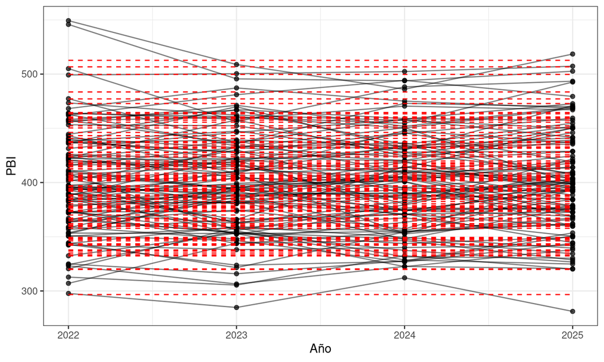

## Efectos Mixtos

Se llaman modelos de efectos mixtos a aquellos que consideran efectos fijos (capturan tendencias grupales) y efectos aleatorios (capturan tendencias individuales).

Los efectos aleatorios se pueden interpretar como desviaciones de la tendencia grupal. Por ejemplo, en este caso,

- un efecto aleatorio **negativo** representa un país que tiene un PBI de base más **bajo** que la tendencia central de la región.
- un efecto aleatorio **positivo** representa un país que tiene un PBI de base más **alto** que la tendencia central de la región.

## Análisis efectos aleatorios

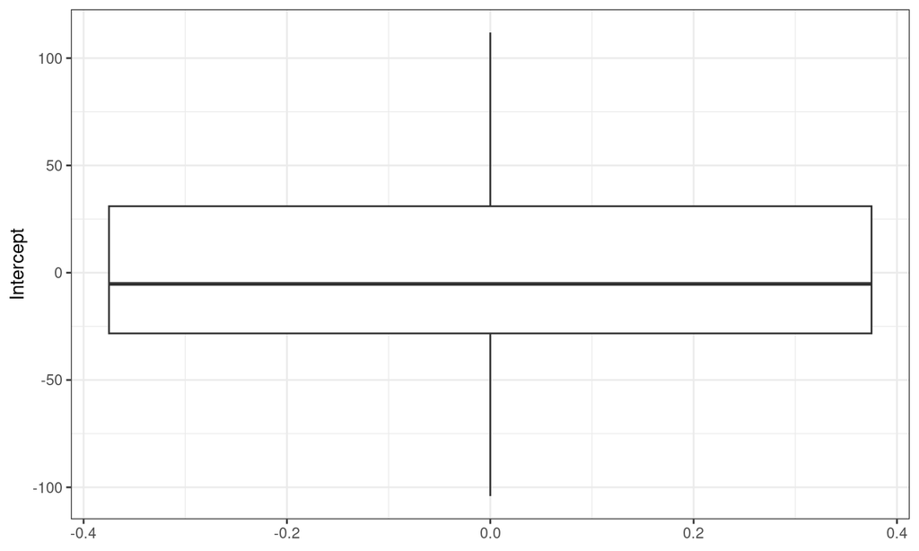

## Tendencias distintas

Supongamos que se obtienen los siguientes datos, donde hay heterogeneidad entre los países, pero no se observa una tendencia constante a lo largo de los años:

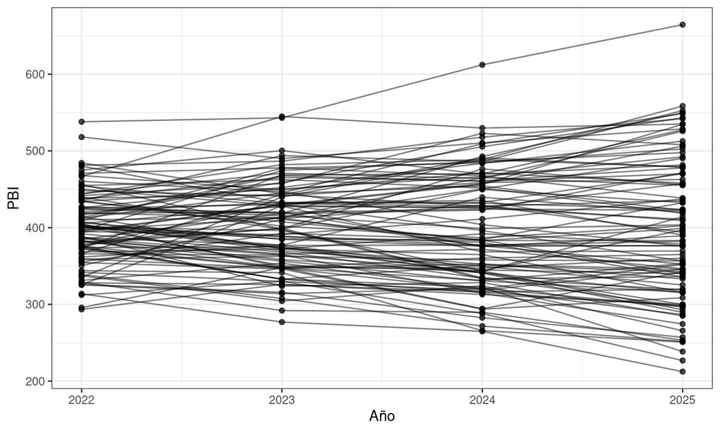

## Correlación

Vemos además, que los datos de un mismo país tienden a estar relacionadas:

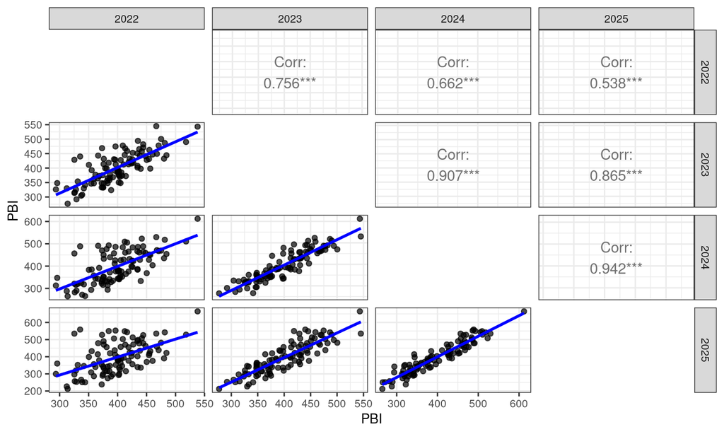

## Modelo de efectos mixtos

En este caso, habría que considerar crecimientos y decrecimientos individuales. Por lo tanto, habría que considerar: \[PBI_{i,j}=\mu + b_{i}+m_{i}\cdot t_{i,j} + \varepsilon_{i,j}\] donde \(t_{i,j}\) representa la cantidad de años pasados desde el año 2022. Esto permite que el valor \(b_{i}\) represente el “punto de partida” y \(m_i\) la pendiente con la que crece o decrece.

## Representación gráfica

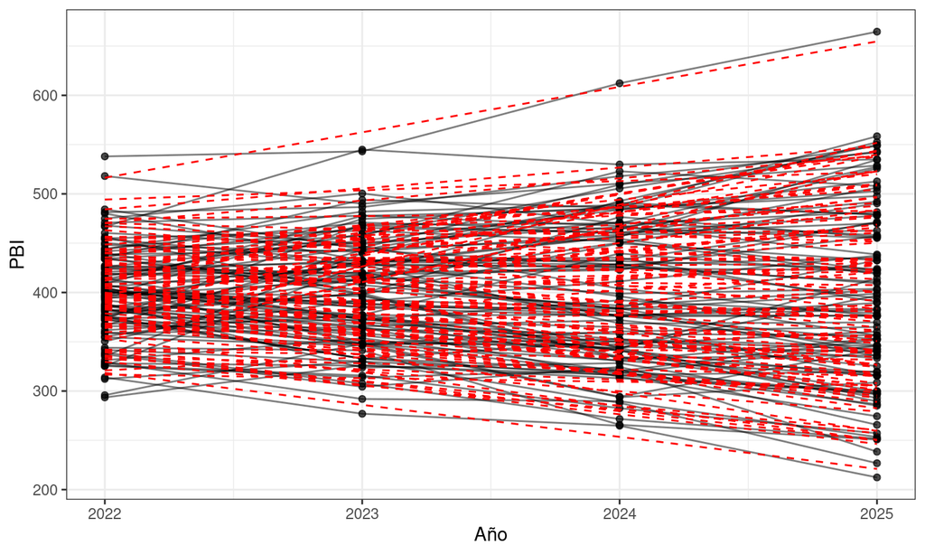

## Interpretación Efectos Aleatorios

En este caso,

- Valores **positivos** de \(b_i\) representan países con un PBI en 2022 **mayor** que el promedio de los países de la región.
- Valores **negativos** de \(b_i\) representan países con un PBI en 2022 **menor** que el promedio de los países de la región.
- Valores **positivos** de \(m_i\) representan países con un **crecimiento** en PBI **mayor** que el promedio de los países de la región.
- Valores **negativos** de \(m_i\) representan países con un **decrecimiento** en PBI mayor (o menor crecimiento) que el promedio de los países de la región.

## Análisis Efectos Aleatorios

En este caso, podemos analizar las ordenadas y pendientes por individuos:

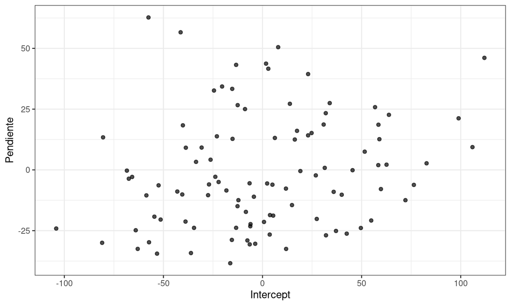

## Correlación

Se puede demostrar que la introducción de efectos aleatorios individuales genera una correlación entre las mediciones repetidas del mismo individuo. Por eso es un modelo muy útil para datos longitudinales.